# Laboratorio 1 Estadística general

Katherine Benjumea Ortiz, Brigith Lorena Giraldo Vargas, Valentina Ochoa Arboleda, Tomás Atehortua Ceferino, Danilo de Jesús Toro Echeverri

2023-02-23

```r
library(readr)
dat <- read_csv("./pizzadelivery.csv")
```

```
## ──────────────────────────────────────────────────────── Delimiter: "," chr
## (5): day, date, operator, branch, driver dbl (8): ...1, time, temperature,
## bill, pizzas, free_wine, got_wine, discoun...
```

## Bloque 1

### Problema 5

- day : cualitativa-nominal
- date : cuantitativa-discreta
- time : cuantitativa-continua
- operator : cualitativa-nominal
- branch : cualitativa-nominal
- driver : cualitativa-nominal
- temperature : cuantitativa-continua
- bill : cuantitativa-continua
- pizzas : cuantitativa-discreta
- free_wine : cualitativa-nominal
- got_wine : cualitativa-nominal
- discount_customer : cualitativa-nominal

## Problema 6

#### Day

Con el gráfico podemos observar que los días en los que mayor número de pedidos se hacen son viernes y sábados, mientras que el miércoles es el día con menor número de pedidos.

```r
(fi_day <- table(dat$day))
```

```
##
##    Friday    Monday  Saturday    Sunday  Thursday   Tuesday Wednesday
##       246       136       246       177       196       133       132
```

```r
(porc_2 <- (fi_day / length(dat$day)) * 100)
```

```
##
##    Friday    Monday  Saturday    Sunday  Thursday   Tuesday Wednesday
##  19.43128  10.74250  19.43128  13.98104  15.48183  10.50553  10.42654
```

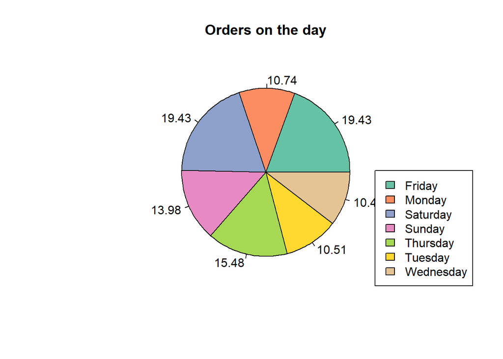

```r
porc_2 <- round(porc_2, 2)
palette("Set 2")
pie(porc_2, porc_2, col = 1:8, main = "Orders on the day")
legend(x = "bottomright", legend = names(fi_day), fill = 1:8)
```

#### Operator

En este caso se puede observar que la operadora Laura recibe mayor número de llamadas, aunque es mínima la diferencia entre operadoras.

```r
(fi_operator <- table(dat$operator))
```

```
##
##   Laura Melissa
##     638     628
```

```r
(porc_2 <- (fi_operator / length(dat$operator)) * 100)
```

```
##
##    Laura  Melissa
## 50.39494 49.60506
```

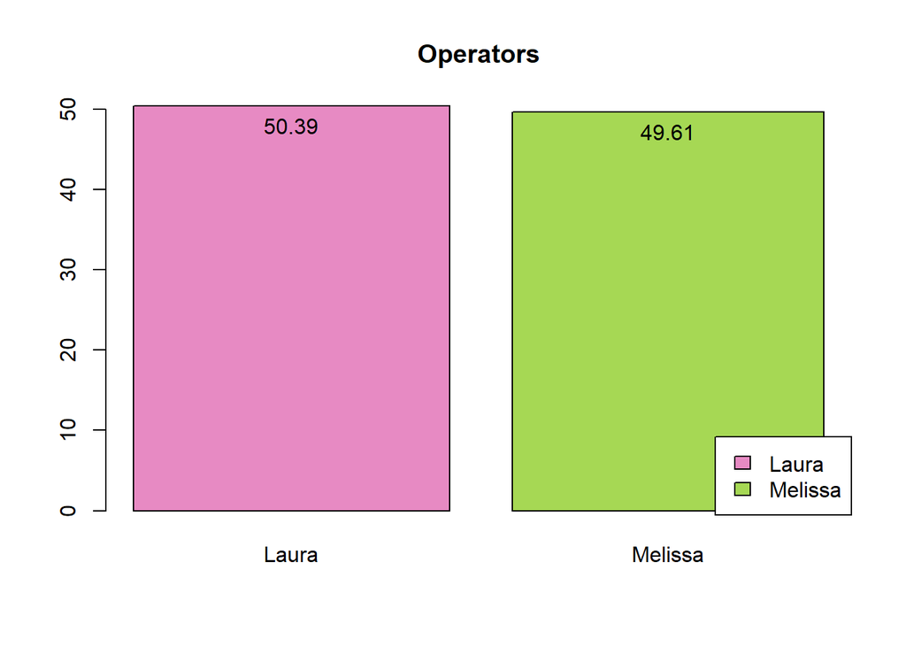

```r
porc_2 <- round(porc_2, 2)
bp0 <- barplot(porc_2, porc_2, col = 4:6, main = "Operators")
text(x = bp0, y = porc_2, labels = porc_2, pos = 1)
legend(x = "bottomright", legend = names(porc_2), fill = 4:6)
```

#### Branch

Analizando la variable de sucursales se puede afirmar que la que se encuentra al oeste de la ciudad es la que recibe y atiende mayor número de pedidos.

```r
library(plotrix)
(fi_branch <- table(dat$branch))
```

```
##
## Centre   East   West
##    421    410    435
```

```r
(porc_2 <- (fi_branch / length(dat$branch)) * 100)
```

```
##
##   Centre     East     West
## 33.25434 32.38547 34.36019
```

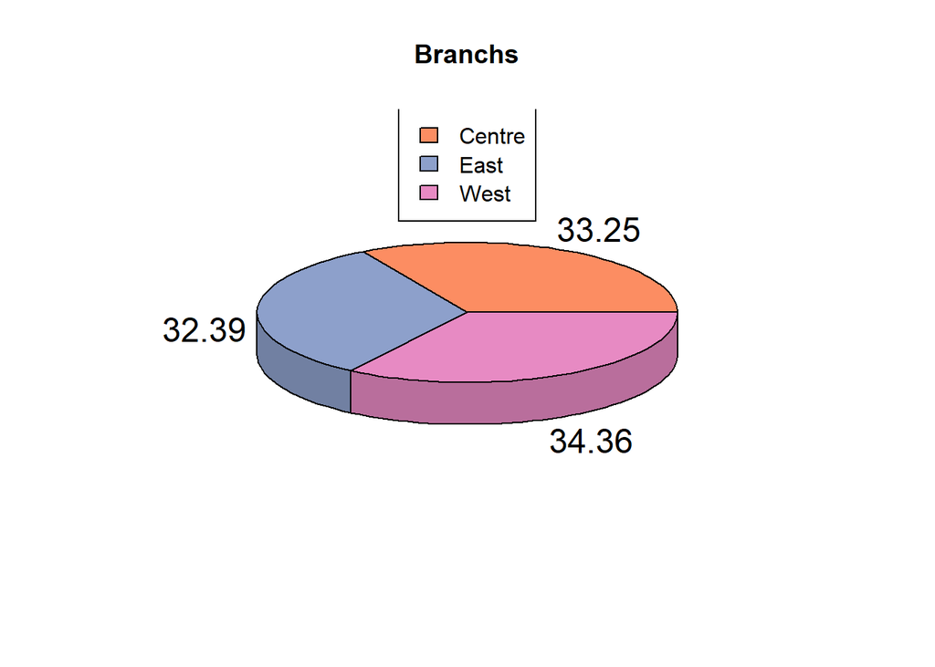

```r
porc_2 <- round(porc_2, 2)
pie3D(porc_2, labels = porc_2, col = 2:9, main = "Branchs")
legend(x = "top", legend = names(fi_branch), fill = 2:9)
```

#### Driver

De acuerdo a la gráfica, el repartidor con mayor número de entregas es Mario mientras que Domenico es el que ha realizado menor número de entregas.

```r
(fi_driver <- table(dat$driver))
```

```
##
##     Bruno  Domenico     Luigi     Mario Salvatore
##       329        93       142       358       344
```

```r
(porc_2 <- (fi_driver / length(dat$driver)) * 100)
```

```
##
##     Bruno  Domenico     Luigi     Mario Salvatore
## 25.987362  7.345972 11.216430 28.278041 27.172196
```

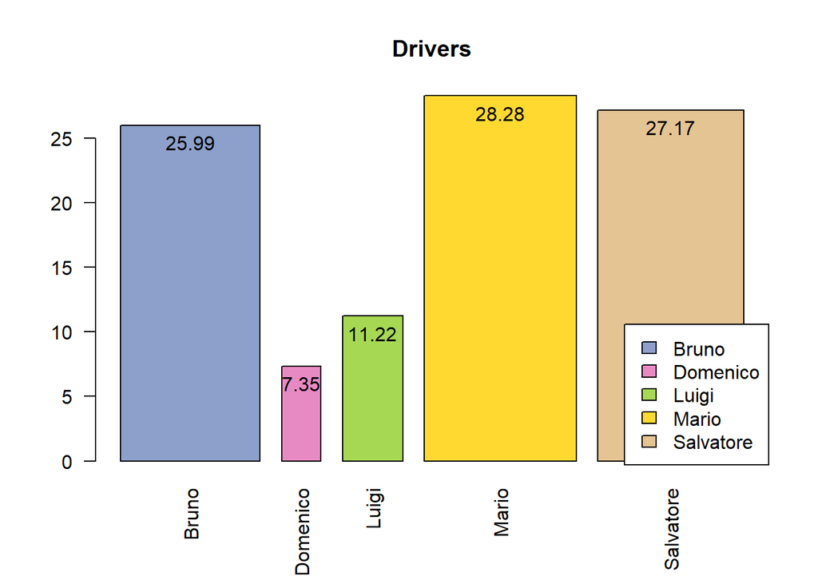

```r
porc_2 <- round(porc_2, 2)
bp1 <- barplot(porc_2, porc_2, col = 3:8, main = "Drivers", las = 2)
text(x = bp1, y = porc_2, labels = porc_2, pos = 1)
legend(x = "bottomright", legend = names(porc_2), fill = 3:8)
```

#### Free_wine

Esta gráfica representa el porcentaje de vinos gratis que prometían ser entregados por los repartidores a los clientes, 1 haciendo referencia a vinos que se tenían que entregar gratis.

```r
library(plotrix)
(fi_freewine <- table(dat$free_wine))
```

```
##
##    0    1
## 1037  229
```

```r
(porc_2 <- (fi_freewine / length(dat$free_wine)) * 100)
```

```
##
##        0        1
## 81.91153 18.08847
```

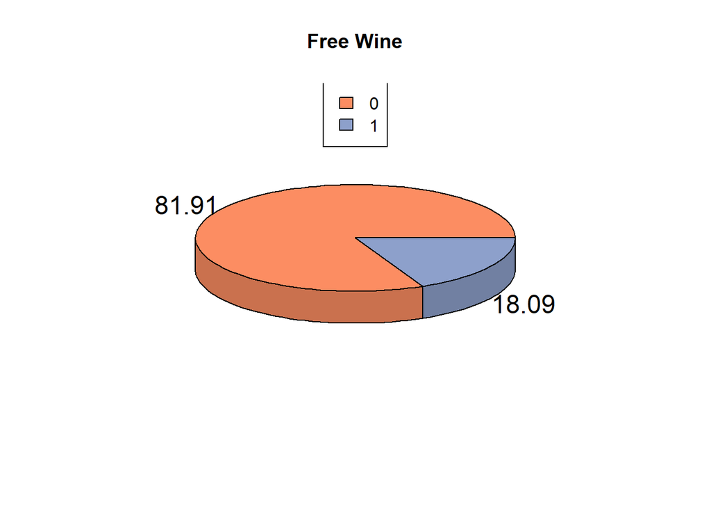

```r
porc_2 <- round(porc_2, 2)
pie3D(porc_2, labels = porc_2, col = 2:9, main = "Free Wine")
legend(x = "top", legend = names(fi_freewine), fill = 2:9)
```

#### Got_wine

La gráfica muestra el porcentaje de botellas de vino gratis que si fueron entregadas a los clientes por los repartidores, siendo 1 el porcentaje de vinos que si fueron entregados.

```r
(fi_gotwine <- table(dat$got_wine))
```

```
##
##    0    1
## 1078  188
```

```r
(porc_2 <- (fi_gotwine / length(dat$got_wine)) * 100)
```

```
##
##        0        1
## 85.15008 14.84992
```

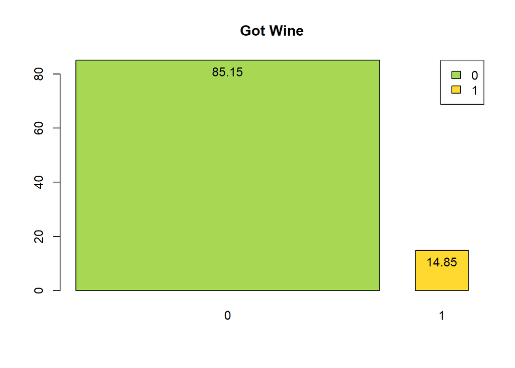

```r
porc_2 <- round(porc_2, 2)
bp3 <- barplot(porc_2, porc_2, col = 5:7, main = "Got Wine")
text(x = bp3, y = porc_2, labels = porc_2, pos = 1)
legend(x = "topright", legend = names(porc_2), fill = 5:7)
```

#### Discount_customer

La gráfica muestra el porcentaje de veces que se hicieron o no descuentos a los clientes, siendo 1 el porcentaje de descuentos asignado.

```r
library(plotrix)
(fi_discountcustomer <- table(dat$discount_customer))
```

```
##
##   0   1
## 990 276
```

```r
(porc_2 <- (fi_discountcustomer / length(dat$discount_customer)) * 100)
```

```
##
##        0        1
## 78.19905 21.80095
```

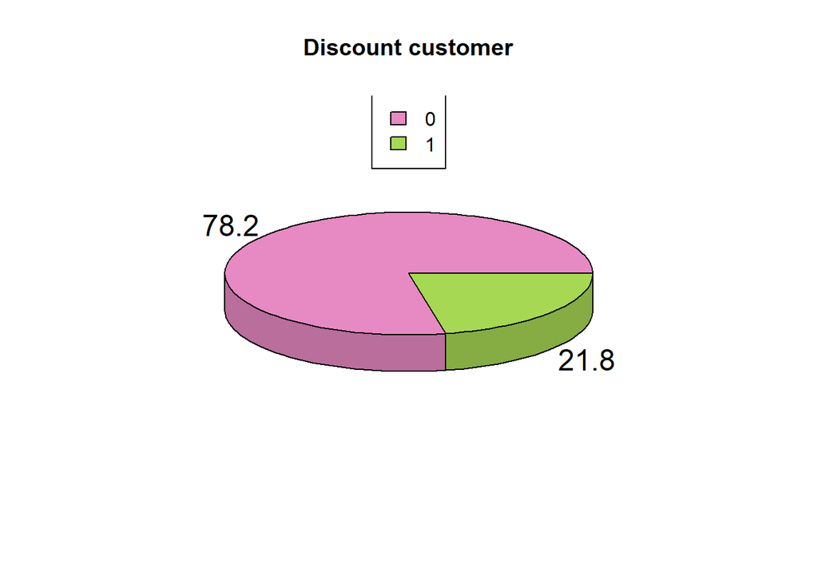

```r
porc_2 <- round(porc_2, 2)
pie3D(porc_2, labels = porc_2, col = 4:6, main = "Discount customer")
legend(x = "top", legend = names(fi_discountcustomer), fill = 4:6)
```

### Problema 7

El repartidor Bruno es el que más botellas de vino gratis tuvo que haber entregado a los clientes y Domenico el que menos botellas gratis tuvo que haber entregado.

```r
datp7 <- dat[dat$free_wine == 1, ]
(p7 <- table(datp7$driver))
```

```
##
##     Bruno  Domenico     Luigi     Mario Salvatore
##        76         6        17        61        69
```

```r
(porc_p7 <- (p7 / length(datp7$driver)) * 100)
```

```
##
##     Bruno  Domenico     Luigi     Mario Salvatore
## 33.187773  2.620087  7.423581 26.637555 30.131004
```

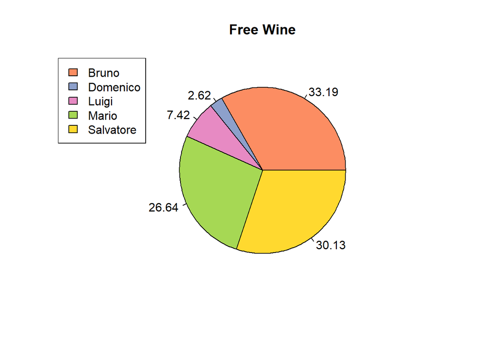

```r
porc_p7 <- round(porc_p7, 2)
pie(porc_p7, labels = porc_p7, col = 2:9, main = "Free Wine")
legend(x = "topleft", legend = names(p7), fill = 2:9)
```

### Problema 8

La sucursal en la que más frecuentemente se dio el hecho de entregar las botellas de vino gratis a los clientes fue la del centro.

```r
datp8 <- dat[dat$free_wine == 1 & dat$got_wine == 1, ]
(p8 <- table(datp8$branch))
```

```
##
## Centre   East   West
##     96     27     65
```

```r
(porc_p8 <- (p8 / length(datp8$branch)) * 100)
```

```
##
##   Centre     East     West
## 51.06383 14.36170 34.57447
```

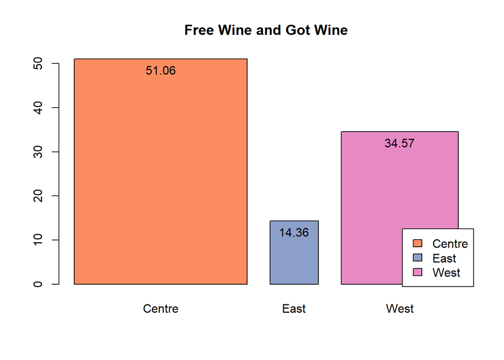

```r
porc_p8 <- round(porc_p8, 2)
bp <- barplot(porc_p8, porc_p8, col = 2:9, main = "Free Wine and Got Wine")
text(x = bp, y = porc_p8, labels = porc_p8, pos = 1)
legend(x = "bottomright", legend = names(porc_p8), fill = 2:9)
```

## Bloque 2

### Problema 9

#### Temperature

```r
temp_list <- dat$temperature
# Calculate information to create frequency table
min <- min(temp_list)
max <- max(temp_list)
length <- length(temp_list)
range <- max - min
class_num <- round(1 + log(length, 2))
class_width <- round(range / class_num, 2)

print(c("Min", min))
```

```
## [1] "Min"  "41.8"
```

```r
print(c("Max", max))
```

```
## [1] "Max"  "87.6"
```

```r
print(c("Length", length))
```

```
## [1] "Length" "1266"
```

```r
print(c("Range", range))
```

```
## [1] "Range" "45.8"
```

```r
print(c("Class Number", class_num))
```

```
## [1] "Class Number" "11"
```

```r
print(c("Class Width", class_width))
```

```
## [1] "Class Width" "4.16"
```

```r
# Calculate intervals and midpoints
sequ <- seq(min, max + class_width, class_width)
intervals <- cut(temp_list, sequ, right = TRUE, include.lowest = TRUE)
abs_freq <- table(intervals)
midpoints <- round((head(sequ, -1) + diff(sequ) / 2), 2)

# Generate frequency table
freq_table <- cbind(
  Mark = midpoints,
  Abs = abs_freq,
  Reltv = round(abs_freq / length(temp_list), 2),
  Acm = cumsum(abs_freq),
  ReAcm = round(cumsum(abs_freq) / length(temp_list))
)

print(freq_table)
```

```
##              Mark Abs Reltv  Acm ReAcm
## [41.8,46]   43.88   5  0.00    5     0
## (46,50.1]   48.04  35  0.03   40     0
## (50.1,54.3] 52.20 107  0.08  147     0
## (54.3,58.4] 56.36 183  0.14  330     0
## (58.4,62.6] 60.52 275  0.22  605     0
## (62.6,66.8] 64.68 309  0.24  914     1
## (66.8,70.9] 68.84 196  0.15 1110     1
## (70.9,75.1] 73.00 107  0.08 1217     1
## (75.1,79.2] 77.16  33  0.03 1250     1
## (79.2,83.4] 81.32  11  0.01 1261     1
## (83.4,87.6] 85.48   4  0.00 1265     1
## (87.6,91.7] 89.64   1  0.00 1266     1
```

### Date

Para el análisis de la variable date, concluimos lo siguiente: La fecha en la que se realizaron más pedidos en el mes de Mayo es 16-May-14 con 56 pedidos. Por otro lado, la fecha con menos pedidos en el mes de Mayo son 05-May-14, 13-May-14, 26-May-14 con 31 pedidos.

```r
table <- table(dat$date)
(cbind(table))
```

```
##           table
## 01-May-14    50
## 02-May-14    51
## 03-May-14    53
## 04-May-14    46
## 05-May-14    31
## 06-May-14    33
## 07-May-14    32
## 08-May-14    36
## 09-May-14    46
## 10-May-14    45
## 11-May-14    42
## 12-May-14    36
## 13-May-14    31
## 14-May-14    32
## 15-May-14    37
## 16-May-14    56
## 17-May-14    52
## 18-May-14    45
## 19-May-14    38
## 20-May-14    36
## 21-May-14    33
## 22-May-14    36
## 23-May-14    45
## 24-May-14    49
## 25-May-14    44
## 26-May-14    31
## 27-May-14    33
## 28-May-14    35
## 29-May-14    37
## 30-May-14    48
## 31-May-14    47
```

#### Time

Por medio del siguiente gráfico, podemos notar como el tiempo más usual de una entrega se tarde entre 28.6 y 36.8 minutos, puesto que el 45% de las pizzas son entregadas en este periodo de tiempo. Por otro lado, lo menos habitual es que una pizza sea entregada en un periodo de 12.3 y 20.5 minutos, ya que solo el 2.21% de las pizzas son entregadas durante este.

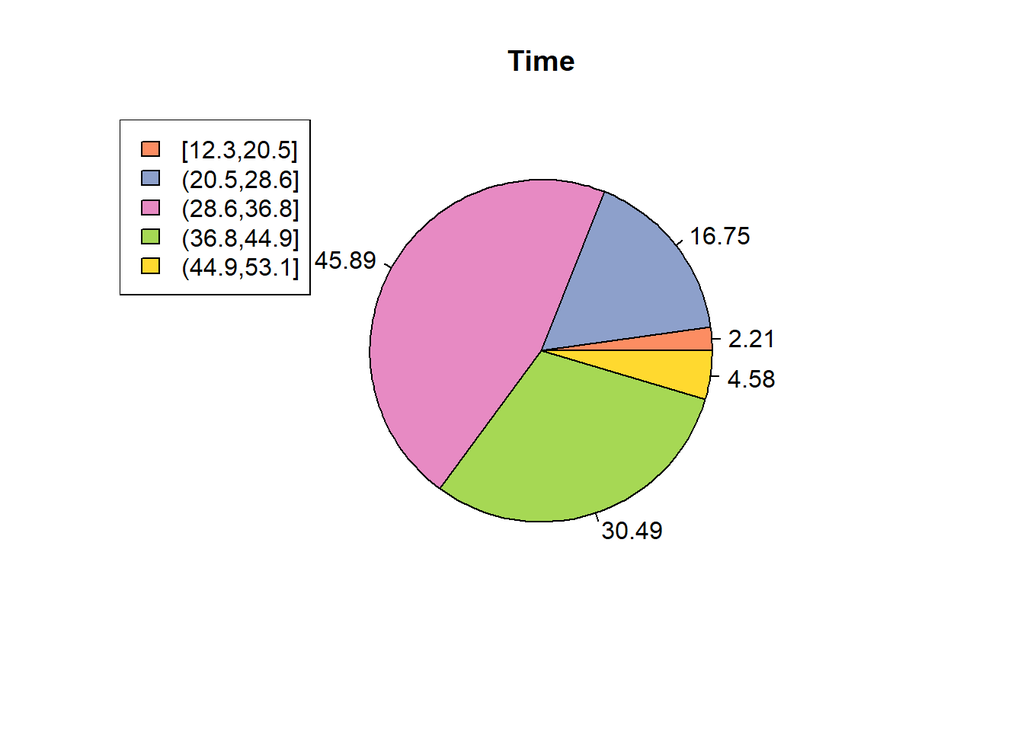

```r
min <- min(dat$time)
max <- max(dat$time)
k <- 5
A <- (max - min) / k

intervals <- cut(dat$time, breaks = seq(min, max, by = A), Right = TRUE, include.lowest = TRUE)

fi <- table(intervals)
porc <- (fi / length(dat$time)) * 100
porc <- round(porc, 2)

pie(porc, porc, col = 2:7, main = "Time")
legend("topleft", legend = names(fi), fill = 2:7)
```

#### Bill

Para el caso de la variable Bill (cuenta), realizamos el análisis de frecuencia mediante el siguiente histograma, describiendo el siguiente comportamiento: - Entre [35, 40) y [45,50) tienen una frecuencia absoluta mayor o igual a 200. - Entre [0, 10) tienen una frecuencia absoluta de 1.

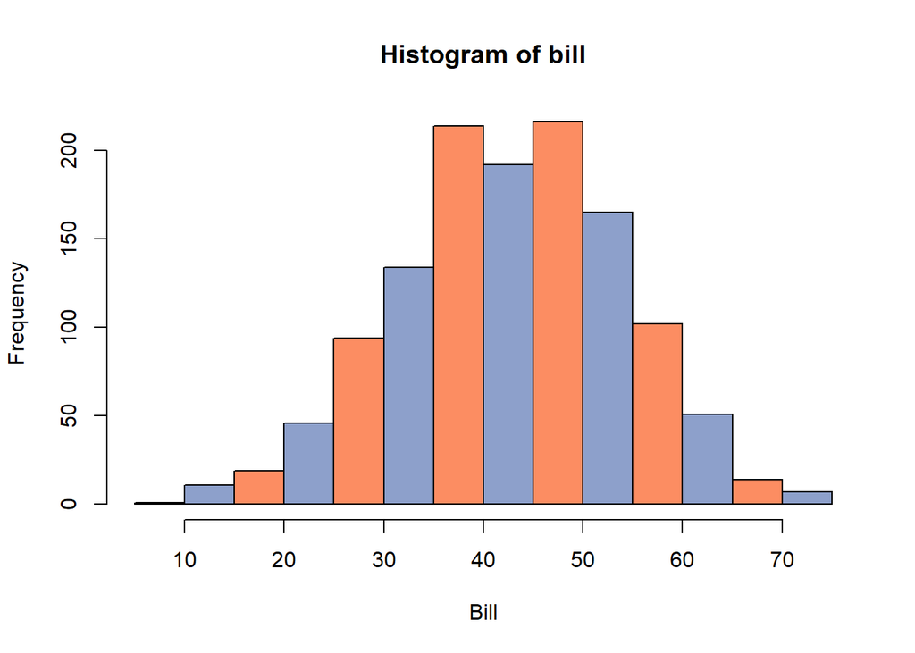

```r
fi <- hist(dat$bill, xlab = "Bill", ylab = "Frequency", main = "Histogram of bill", col = 2:3)
```

#### Pizzas

Para finalizar, en el caso de la variable “pizzas”, nos encontramos con que la cantidad pedida con mayor frecuencia va de un rango de 2 a 3 pizzas por orden. A su vez, podemos ver en la siguiente ilustración como el número de 8, 9 y 11 pizzas son las cantidades más inusuales en la tienda.

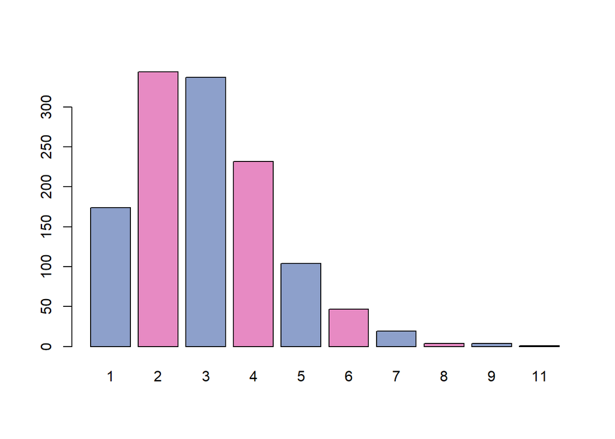

```r
fi <- table(dat$pizzas)
hi <- fi / length(dat$pizzas)
porc <- (fi / length(dat$pizzas)) * 100
barplot(fi, col = 3:4)
```

### Problema 10

La central que ha llegado a valores altos de temperatura es la sede East. Estando en el intervalo de (81.8, 91.8]. Por otro lado, la temperatura con mayor aparicion en las sedes se encuentran en el intervalo de (61.8, 71.8], seguido por el intervalo (51.8, 61.8].

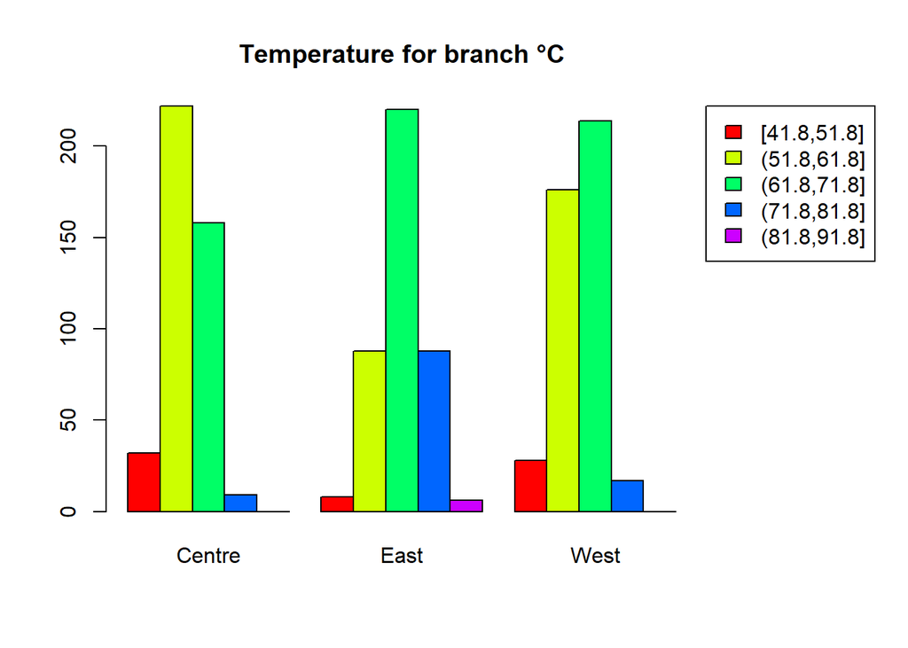

```r
get_intervals <- function(sublist) {
  min <- min(sublist)
  max <- max(sublist)
  sequ <- seq(min, max + 10, 10)
  intervals <- cut(sublist, sequ, right = TRUE, include.lowest = TRUE)
  return(intervals)
}
intervals <- get_intervals(temp_list)
table <- table(intervals, dat$branch)
par(mar = c(5.1, 4.1, 4.1, 8.1), xpd = TRUE)
barplot(table,
  beside = T, col = rainbow(5), main = "Temperature for branch °C", legend.text = TRUE,
  args.legend = list(x = "topright", inset = c(-0.3, 0))
)
```

### Problema 11

Se han entregado más pizzas los fines de semana (Viernes, Sábado y Domingo) que en el resto de la semana.

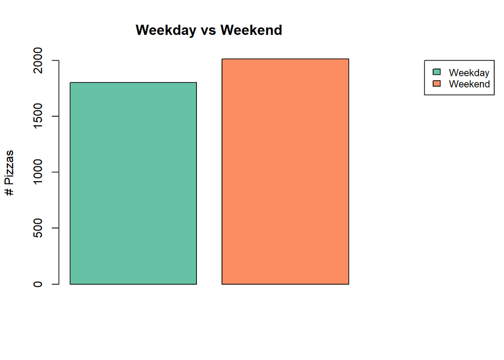

```r
dat$weekend <- ifelse(dat$day == "Friday" | dat$day == "Saturday" | dat$day == "Sunday", 1, 0)

weekend_pizzas <- sum(dat[dat$weekend == 1, 10])
weekday_pizzas <- sum(dat[dat$weekend == 0, 10])

par(mar = c(5.1, 4.1, 4.1, 10), xpd = TRUE)
barplot(c(weekday_pizzas, weekend_pizzas), main = "Weekday vs Weekend", col = 1:2, ylab = "# Pizzas")
legend(3, 2000,
  legend = c("Weekday", "Weekend"),
  col = 1:2, cex = 0.8, inset = c(-0.3, 0), fill = 1:2
)
```

Se ha conseguido mayor ganancia los fines de semana (Viernes, Sábado y Domingo) que en el resto de la semana. Era de esperarse debido a que existe mayor demanda de pizzas los fines de semana.

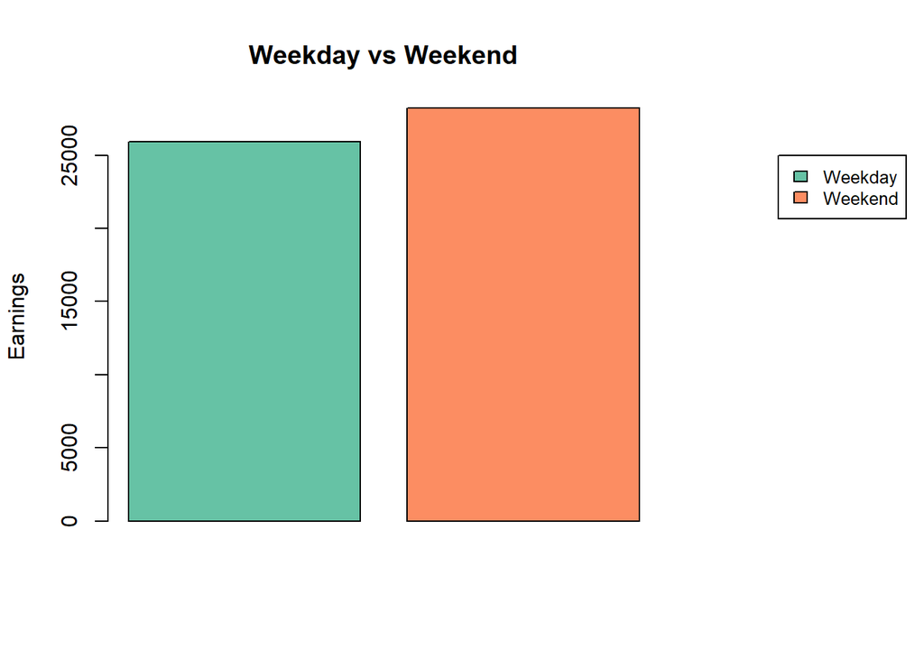

```r
weekend_bill <- sum(dat[dat$weekend == 1, 9])
weekday_bill <- sum(dat[dat$weekend == 0, 9])

par(mar = c(5.1, 4.1, 4.1, 10), xpd = TRUE)
barplot(c(weekday_bill, weekend_bill), main = "Weekday vs Weekend", col = 1:2, ylab = "Earnings")
legend(3, 25000,
  legend = c("Weekday", "Weekend"),
  col = 1:2, cex = 0.8, inset = c(-0.3, 0), fill = 1:2
)
```

## Bloque 3

### Problema 12

#### Variable Temperature

- mean = promedio de la variable de temperature.
- median = medida central del conjunto de datos organizados de la variable temperature.
- min = mínimo del conjunto de datos organizados de la variable temperature.
- max = máximo del conjunto de datos organizados de la variable temperature.
- desv = nos indica que la mayor parte de los datos de la variable temperature tienden a estar agrupados cerca de 6.906258.
- range = se puede observar la dispersión total que se tiene en el conjunto de datos de la variable temperature
- var = Muestra una medida de dispersión en el conjunto de datos de la variable temperature
- quantiles = El porcentaje de los datos que están en el cuartil 1 (0-25) es de 58.2

#### Variable Time

```r
# Temperature
temp_list <- dat$temperature
mean <- mean(temp_list) # 62.86343
median <- median(temp_list) # 62.9
min <- min(temp_list) # 41.8
max <- max(temp_list) # 87.6
desv <- sd(temp_list) # 6.906258
range <- max - min # 45.8
var <- var(temp_list) # 47.69639
quantiles <- quantile(temp_list, c(0.25), type = 6) # 25% 58.2

# Time
time_list <- dat$time
mean <- mean(time_list) # 34.22915
median <- median(time_list) # 34.4
min <- min(time_list) # 12.3
max <- max(time_list) # 53.1
desv <- sd(time_list) # 6.461669
range <- max - min # 40.8
var <- var(time_list) # 41.75317
quantiles <- quantile(temp_list, c(0.25), type = 6) # 25% 30.075
```

## Problema 13

Se puede observar en la siguiente tabla como la temperatura con la que es entregada las pizzas, varía considerablemente entre semana y fin de semana. Puesto en los días como viernes, sábado y domingo la mayoría de las pizzas son entregadas con una temperatura amena para el cliente. Variando entre 61.8 a 71.8 grados Celsius, sin embargo también se entrega mayor cantidad de pizzas frías a comparación con los días de la semana. Esto posiblemente sea por la alta demanda de pizzas de la tienda en los fines de semana.

```r
# Temperature -> weekday - weekend
# min= min(temp_list)
# max = max(temp_list)
# sequ = seq(min, max + 10, 10)
# intervals = cut(temp_list, sequ, right = TRUE, include.lowest = TRUE)

intervals <- get_intervals(temp_list)
table <- table(intervals, dat$day)
print(table)
```

```
##
## intervals     Friday Monday Saturday Sunday Thursday Tuesday Wednesday
##   [41.8,51.8]     17      8       14      8        8       5         8
##   (51.8,61.8]     93     55      103     61       75      44        55
##   (61.8,71.8]    113     56      111     79      100      72        61
##   (71.8,81.8]     22     16       18     28       12      10         8
##   (81.8,91.8]      1      1        0      1        1       2         0
```

```r
table <- table(intervals, ifelse(dat$weekend == 1, "Weekend", "Weekday"))
print(table)
```

```
##
## intervals     Weekday Weekend
##   [41.8,51.8]      29      39
##   (51.8,61.8]     229     257
##   (61.8,71.8]     289     303
##   (71.8,81.8]      46      68
##   (81.8,91.8]       4       2
```

```r
# Time -> weekday - weekend
# min= min(time_list)
# max = max(time_list)
# sequ = seq(min, max + 10, 10)
# intervals = cut(time_list, sequ, right = TRUE, include.lowest = TRUE)
intervals <- get_intervals(time_list)
table <- table(intervals, dat$day)
print(table)
```

```
##
## intervals     Friday Monday Saturday Sunday Thursday Tuesday Wednesday
##   [12.3,22.3]      3      9        7      7       10       7         6
##   (22.3,32.3]     99     55       85     66       56      36        38
##   (32.3,42.3]    118     63      127     89      108      75        74
##   (42.3,52.3]     26      9       27     14       22      15        14
##   (52.3,62.3]      0      0        0      1        0       0         0
```

```r
table <- table(intervals, ifelse(dat$weekend == 1, "Weekend", "Weekday"))
print(table)
```

```
##
## intervals     Weekday Weekend
##   [12.3,22.3]      32      17
##   (22.3,32.3]     185     250
##   (32.3,42.3]     320     334
##   (42.3,52.3]      60      67
##   (52.3,62.3]       0       1
```

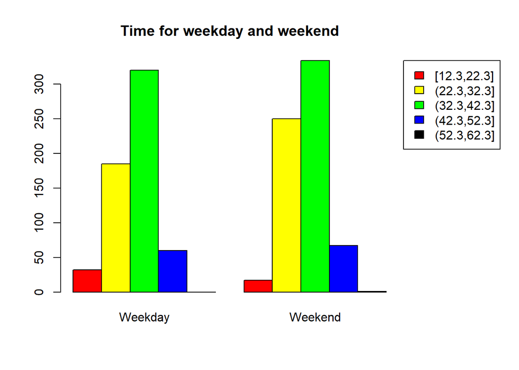

```r
par(mar = c(5.1, 4.1, 4.1, 8.1), xpd = TRUE)
barplot(table,
  beside = T, col = c("red", "yellow", "green", "blue", "black"), main = "Time for weekday and weekend", legend.text = TRUE,
  args.legend = list(x = "topright", inset = c(-0.3, 0))
)
```

Analizando los tiempos de entrega entre las diferentes sedes, hay una notable diferencia entre las sedes West, East y Centre. Ya que a pesar de que la sede East no es de las que más número de pizzas vende, es la que más rápido las entrega, llegando al punto de entregar 41 pizzas en un intervalo de 12.3 y 22.3 minutos (algo inusual en las demás sedes). Por otro lado, la sede Centre tiene los peores tiempos de entrega comparado con sus hermanas, esto probablemente debido a su contante demanda de pizzas todos los días de la semana.

```r
# Time -> branch
# min = min(time_list)
# max = max(time_list)
# sequ = seq(min, max + 10, 10)
# intervals = cut(time_list, sequ, right = TRUE, include.lowest = TRUE)
intervals <- get_intervals(time_list)
table <- table(intervals, dat$branch)
print(table)
```

```
##
## intervals     Centre East West
##   [12.3,22.3]      3   41    5
##   (22.3,32.3]    103  190  142
##   (32.3,42.3]    246  166  242
##   (42.3,52.3]     69   13   45
##   (52.3,62.3]      0    0    1
```

Teniendo esta información y la de la tabla anterior (tiempo de entrega por sede), podemos decir que la sede East es la mejor sede de las 3, ya que además de entregar sus pizzas más rápido, las entregas más calientes.

```r
# Temperature -> branch
# min = min(temp_list)
# max = max(temp_list)
# sequ = seq(min, max + 10, 10)
# intervals = cut(temp_list, sequ, right = TRUE, include.lowest = TRUE)
intervals <- get_intervals(temp_list)
table <- table(intervals, dat$branch)
print(table)
```

```
##
## intervals     Centre East West
##   [41.8,51.8]     32    8   28
##   (51.8,61.8]    222   88  176
##   (61.8,71.8]    158  220  214
##   (71.8,81.8]      9   88   17
##   (81.8,91.8]      0    6    0
```

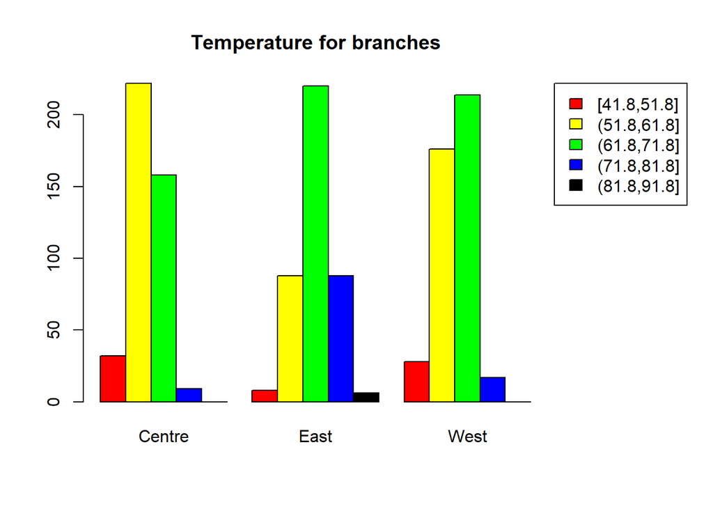

```r
par(mar = c(5.1, 4.1, 4.1, 8.1), xpd = TRUE)
barplot(table,
  beside = T, col = c("red", "yellow", "green", "blue", "black"), main = "Temperature for branches", legend.text = TRUE,
  args.legend = list(x = "topright", inset = c(-0.3, 0))
)
```

## Problema 14

Teniendo en cuenta el tiempo de entrega de cada repartidor durante el mes de mayo, se puede deducir que el que tuvo mejor rendimiento fue Domenico ubicándose en el cuartil inferior; es decir, Domenico es el que se más cerca al mínimo de datos del tiempo, por lo tanto, se entiende que fue el que tuvo mejor rendimiento respecto a esta variable.

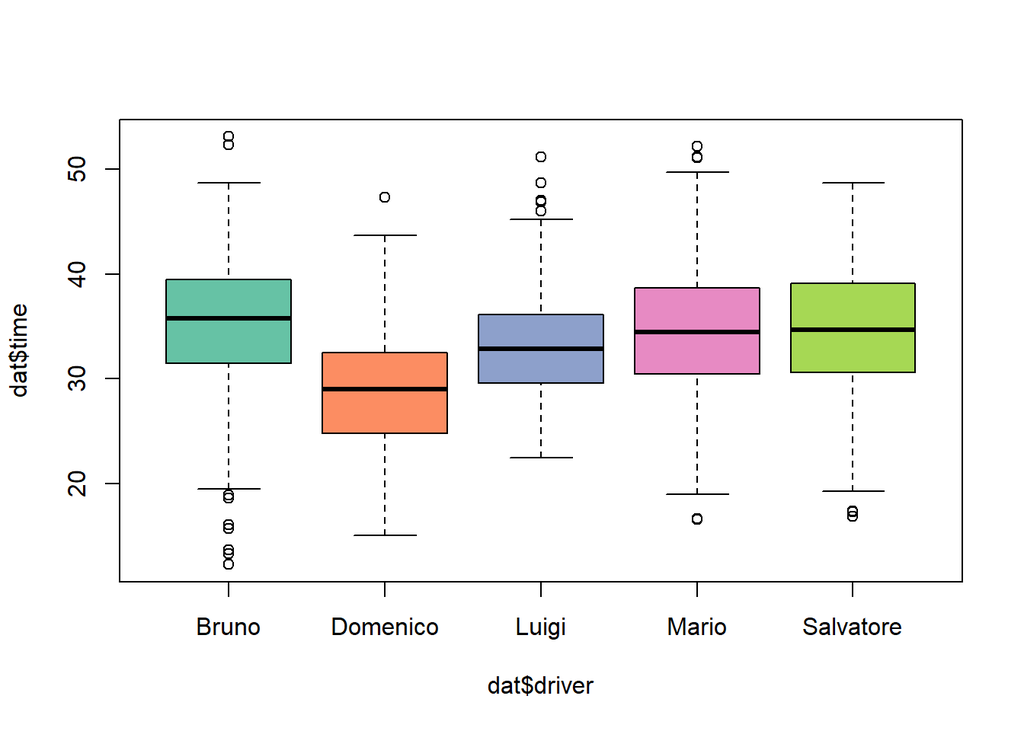

```r
boxplot(dat$time ~ dat$driver, horizontal = FALSE, border = par("fg"), col = 1:6, log = "")
```